# Week #13- Exponential Smoothing Methods

# 4 Holt’s Smoothing Model: Linear (additive) Trend

Holt generalized simple exponential smoothing by adding a trend parameter to allow the forecasting of data with a linear trend. The model components are given in the following:

- Forecast function: $\hat{y}_{t+h|t} = \mathfrak{l}_t + h b_t$.
- Level: $\mathfrak{l}_t = \alpha y_t + (1-\alpha)(\mathfrak{l}_{t-1} + b_{t-1})$.
- Trend: $b_t=\beta^*(\mathfrak{l}_t-\mathfrak{l}_{t-1}) + (1-\beta^*)b_{t-1}$.
- Error: $e_t = y_t-{\mathfrak{l}_{t-1} + b_t} = y_t-\hat{y}_{t|t-1}$.

where $\alpha$ is the smoothing coefficient for level and $\beta^*$ the smoothing coefficient of trend. The smoothing coefficients are estimated by minimizing the sum of the squared error (SSE) of the model.

The R function **holt()** computes the smoothing coefficients and forecasts future values for a given $h$ period of future values.

**Example 2**: We apply Holt’s method to annual passenger numbers for Australian airlines from 1990 to 2016.

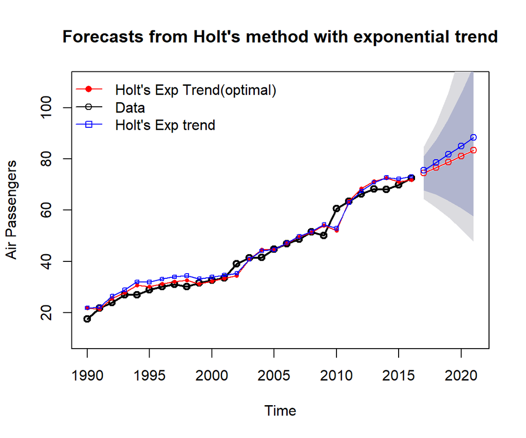

Comparing Holt’s exponential trend models with various smoothing coefficients.

```r
ausair=read.table("https://raw.githubusercontent.com/pengdsci/sta321/main/ww13/w13-ausair.txt")[,3]
air = ts(ausair,start=1990,end=2016)
fit0 = holt(air, initial="simple", exponential=TRUE,h=5)  ### optimal alpha and beta
fit1 = holt(air, alpha=0.8, beta=0.2, exponential=TRUE, initial="simple", h=5)
###### Plot the original data
plot(fit0, lwd=2,type="o", ylab="Air Passengers", xlab="Time",
     fcol="white", ylim=c(10, 110))
lines(fitted(fit0), col="red")
lines(fitted(fit1), col="blue")
#points(fit0, col="black", pch=1)
points(fitted(fit0), col="red", pch=16, cex=0.6)
points(fitted(fit1), col="blue", pch=22, cex=0.6)
#######################
lines(fit0$mean, col="red", type="o")
lines(fit1$mean, col="blue", type="o")
legend("topleft", lty=1, col=c("red","black","blue"),pch=c(16,1,22),
   c("Holt's Exp Trend(optimal)","Data","Holt's Exp trend"), bty="n")
```

# 5 Damped Trend Methods

Empirical evidence indicates that these methods tend to over-forecast, especially for longer forecast horizons. Gardner’s damped trend models are shown to be effective in improving accuracy for prediction.

To capture the damped trend (the trend component curve flattens over time instead of being linear), in addition to the two smoothing parameters $\alpha$ and $\beta^*$ in linear and exponential trend models, Gardener added a third parameter $\phi$ ($0< \phi < 1$) that damps the trend as h gets bigger.

**For an additive (linear) trend model**, the additional parameter is added in the model component in the following form.

- Forecast Model: $\hat{y}_{t+h|t} = \mathfrak{l}_t + (1 + \phi+\phi^2|\cdots+\phi^h)b_t$
- Level: $\mathfrak{l}_t = \alpha y_t + (1-\alpha)(\mathfrak{l}_{t-1}+\phi b_{t-1})$
- Trend: $b_t = \beta^* (\mathfrak{l}_t-\mathfrak{l}_{t-1}) + (1-\beta^*)\phi b_{t-1}$. where $\phi$ is called the **damping parameter**.

Let error $e_t = y_t-(\mathfrak{l}_{t-1}+b_{t-1})=y_t-\hat{y}_{t|t-1}$, then the level and trend can be re-expressed as

- Level: $\mathfrak{l}_t = \mathfrak{l}_{t-1} + \phi b_{t-1} + \alpha e_t$.
- Additive Trend: $b_t=\phi b_{t-1} + \alpha \beta^* e_t$.

**For a multiplicative (exponential) trend mode**, the additional parameter is added in the model component in the following form.

- Forecast Model: $\hat{y}_{t+h|t} = \mathfrak{l}_t b_{t}^{(1 + \phi+\phi^2|\cdots+\phi^h)}$.
- Level: $\mathfrak{l}_t = \alpha y_t + (1-\alpha)\mathfrak{l}_{t-1}b_{t-1}^\phi$
- Multiplicative Trend: $b_t=\beta^*\mathfrak{l}_t/\mathfrak{l}_{t-1} + (1-\beta^*) b_{t-1}^\phi$.

Since this is a modification of the smoothing model with the exponential trend, $b_t$ and $h$ are interpreted in the same way as in the exponential trend smoothing model and $\phi$ is between 0 and 1, exclusively.

Let error $e_t = y_t - \hat{y}_{t-1|t} = y_t-\mathfrak{l}_{t-1}b_{t-1}$. The corresponding error correction form is given by

- Level: $\mathfrak{l}_t = \alpha e_t + \mathfrak{l}_{t-1} b_{t-1}^\phi$.
- Multiplicative Trend: $b_t = b_{t-1}^\phi + \alpha\beta^* e_t/\mathfrak{l}_{t-1}$

**Example 3**: We use Australian GDP data as an example to illustrate the application of the R function holt() for the damped trend models (both additive and multiplicative models).

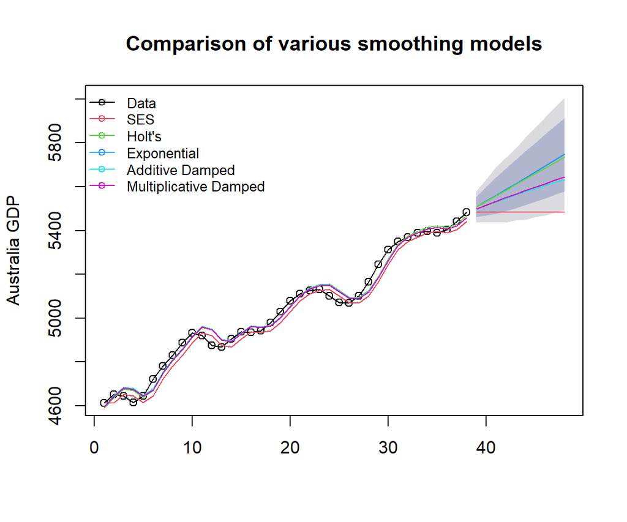

Comparing Holt’s exponential damped trend models.

```r
ausgdp = read.table("https://raw.githubusercontent.com/pengdsci/sta321/main/ww13/w13-ausgdp.txt")
ausgdp0=ts(ausgdp$V1,frequency=4,start=1971+2/4)
ausgdp1=ausgdp$V1
fit1 = ses(ausgdp1)
fit2 = holt(ausgdp1)
fit3 = holt(ausgdp1,exponential=TRUE)
fit4 = holt(ausgdp1,damped=TRUE)      ## additive damping
fit5 = holt(ausgdp1,exponential=TRUE,damped=TRUE)  ## multiplicative dampling
###
plot(fit3, type="o", ylab="Australia GDP",flwd=1,
main="Comparison of various smoothing models")
lines(fitted(fit1),col=2)
lines(fitted(fit2),col=3)
lines(fitted(fit4),col=5)
lines(fitted(fit5),col=6)
######
lines(fit1$mean,col=2)
lines(fit2$mean,col=3)
lines(fit4$mean,col=5)
lines(fit5$mean,col=6)
legend("topleft", lty=1, pch=1, col=1:6,
    c("Data","SES","Holt's","Exponential",
      "Additive Damped","Multiplicative Damped"), cex=0.8, bty="n")
```

```r
accuracy.table = round(rbind(accuracy(fit1), accuracy(fit2), accuracy(fit3),
                             accuracy(fit4), accuracy(fit5)),4)
row.names(accuracy.table)=c("SES","Holt's","Exponential",
                    "Additive Damped","Multiplicative Damped")
kable(accuracy.table, caption = "The accuracy measures of various exponential
      smoothing models")
```

The accuracy measures of various exponential smoothing models

|  | ME | RMSE | MAE | MPE | MAPE | MASE | ACF1 |
| --- | --- | --- | --- | --- | --- | --- | --- |
| SES | 22.8967 | 38.5522 | 32.1076 | 0.4518 | 0.6392 | 0.9738 | 0.5930 |
| Holt’s | -1.1647 | 31.0537 | 26.0678 | -0.0248 | 0.5227 | 0.7906 | 0.6132 |
| Exponential | -0.6055 | 31.2007 | 26.2099 | -0.0140 | 0.5247 | 0.7949 | 0.6100 |
| Additive Damped | -0.8253 | 31.4965 | 25.5226 | -0.0232 | 0.5113 | 0.7740 | 0.6218 |
| Multiplicative Damped | 0.6962 | 31.3254 | 25.7591 | 0.0084 | 0.5160 | 0.7812 | 0.6189 |

# 6 Holt-Winters Model for Trend and Seasonal Data

Holt and Winter’s exponential smoothing method is used to deal with time series containing both trend and seasonal variation. There are two Holt-Winter (HW) models: Additive and Multiplicative models.

**The additive method** is preferred when the seasonal variations are roughly constant through the series, while **the multiplicative method** is preferred when the seasonal variations are changing proportionally to the level of the series.

The Holt-Winters seasonal method comprises the forecast equation and three smoothing equations — one for the level $\mathfrak{l}_t$, one for trend $b_t$, and one for the seasonal component denoted by $s_t$, with smoothing parameters $\alpha$, $\beta^*$ and $\gamma$.

**Additive Holt-Winters Model** Components of additive HW model:

- Level: $\mathfrak{l}_t = \alpha(y_t-s_{t-s})+(1-\alpha)(\mathfrak{l}_{t-1} + b_{t-1})$.
- Trend: $b_t=\beta^*(\mathfrak{l}_t-\mathfrak{l}_{t-1})+(1-\beta^*)b_{t-1}$.
- Seasonality: $s_t=\gamma(y_t-\mathfrak{l}_{t-1}) +(1-\gamma)s_{t-s}$.
- Forecast Model: $\hat{y}_{t+h|t} = \mathfrak{l}_t + hb_t + s_{t-s+h}$.

where $s$ is the length of the seasonal cycle, for $0 \le \alpha \le 1$ , $0 \le \beta^* \le 1$, and $0 \le \gamma \le 1$. $h$ is the number of periods to be predicted.

Let $e_t=\hat{y}_t - \hat{y}_{t|t-1} = y_t-(\mathfrak{l}_{t-1} + b_{t-1} + s_{t-1})$ be the one-step training error, we can re-express level, trend and seasonality equation in the following form:

- Level: $\mathfrak{l}_t= \mathfrak{l}_{t-1} + b_{t-1} + \alpha e_t$.
- Trend: $b_t = b_{t-1} + \alpha \beta^* e_t$.
- Seasonality: $s_t = s_{t-2} + \gamma e_t$.

Interpretations of individual components:

**Level**: the current level is the weighted average of the difference between the current observation and previous seasonality and the sum of the previous level and trend.

**Trend**: the current trend is the weighted average of the previous trend and the difference between the current level and the previous level.

**Seasonality**: the current seasonality is the weighted average of the previous seasonality and the difference between the current observation and the current level.

**Multiplicative Holt-Winters Model**: An alternative Holt-Winter’s model multiplies the forecast by a seasonal factor. Its equations are:

- Level: $\mathfrak{l}_t=\alpha y_t/s_{t-s} + (1-\alpha)(\mathfrak{l}_{t-1}+b_{t01})$.
- Trend: $b_t = \beta^*(\mathfrak{l}_t - \mathfrak{l}_{t-1}) + (1-\beta^*)b_{t-1}$.
- Seasonality: $s_t = \gamma y_t/(\mathfrak{l}_{t-1}+b_{t-1}) + (1-\gamma)s_{t-s}$.
- Forecast Model: $\hat{y}_{t+h|t} = (\mathfrak{l}_t + h b_t)s_{t-s-h}$.

where $s$ is the length of the seasonal cycle, for $0 \le \alpha \le 1$ , $0 \le \beta^* \le 1$, and $0 \le \gamma \le 1$. $h$ is the number of periods to be predicted.

Similarly, we denote the one-step error for the multiplicative model to be $e_t=\hat{y}_t-\hat{y}_{t|t-1} = y_t -(\mathfrak{l}_{t-1}+b_{t-1} + s_{s-t})$, the error correction representation of the model can be written as

- Level: $\mathfrak{l}_t = \mathfrak{l}_{t-1} + b_{t-1} + \alpha e_t/s_{t-s}$.
- Trend: $b_t = b_{t-1} + \alpha\beta^* e_t / s_{t-s}$.
- Seasonality: $s_t = s_{t-s} + \gamma e_t /(\mathfrak{l}_{t-1}+b_{t-1})$.

**Holt-Winters Model with a Damped Trend and Multiplicative Seasonality**. This is a simple modification of the HW multiplicative model with a damped trend. The model formulation is given below

- Level: $\mathfrak{l}_t = \alpha y_t/s_{t-s} + (1-\alpha)(\mathfrak{l}_{t-1}+\phi b_{t-1})$.
- Trend: $b_t = \beta^*(\mathfrak{l}_t - \mathfrak{l}_{t-1}) + (1-\beta^*)\phi b_{t-1}$.
- Seasonality: $s_t = \gamma y_t/(\mathfrak{l}_{t-1}+\phi b_{t-1}) + (1-\gamma)s_{t-s}$.
- Forecast Model: $\hat{y}_{t+h|t}=\left[\mathfrak{l}_t +(1 + \phi +\phi^2+ \cdots + \phi^h)b_t \right]s_{t-s+h}$.

where $0< \phi < 1$.

Three R functions can be used to fit Holt-Winters model: **hw()**,**ets()**, and **HoltWinters()** in package **{forecast}**.

- The estimation of parameters used in function **HoltWinters()** uses **optim()** which requires the initial values for the parameters $\alpha$, $\beta^*$ and $\gamma$. The default initial values of these parameters are 0.3, 0.1, and 0.1. You can provide your own more accurate values. **HoltWinters()** is using heuristic values for the initial states and then estimating the smoothing parameters by optimizing the MSE.
- **ets()** also use **optim()** to estimate the parameters and the initial states by optimizing the likelihood function (which is only equivalent to optimizing the MSE for the linear additive models).
- **hw()** has the option to fit a HW model with a damped trend. **HoltWinters()** does not have the option.

**Example 4**: We use a simulated time series to illustrate how to R functions to fit various HW models.

**HW models**: additive, multiplicative and damped HW models with R function **hw()**.

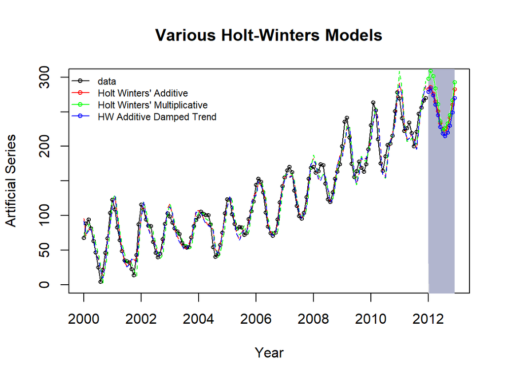

Comparing Holt-Winter’s (damped) trend and seasonal models.

```r
dat01=read.table("https://raw.githubusercontent.com/pengdsci/sta321/main/ww13/w13-ts3.txt")
datset=ts(dat01$V1+55, start=2000, frequency=12)
## Model building
fit1 = hw(datset,h=12, seasonal="additive")   # default h = 10
fit2 = hw(datset,h=12, seasonal="multiplicative")
fit3 = hw(datset,h=12, seasonal="additive",damped=TRUE)
### plots
plot(fit2,ylab="Artificial Series",main="Various Holt-Winters Models",
     type="o", fcol="white", xlab="Year", ylim=c(0,300), cex = 0.6)
lines(fitted(fit1), col="red", lty=2, cex = 0.6)
lines(fitted(fit2), col="green", lty=2, cex = 0.6)
lines(fitted(fit3), col="blue", lty=2, cex = 0.6)
lines(fit1$mean, type="o", col="red", cex = 0.6)
lines(fit2$mean, type="o", col="green", cex = 0.6)
lines(fit3$mean, type="o", col="blue", cex = 0.6)
###
legend("topleft",lty=1, pch=1, col=c("black", "red", "green", "blue"),
  c("data","Holt Winters' Additive","Holt Winters' Multiplicative",
    "HW Additive Damped Trend"), cex=0.7, bty = "n")
```

The accuracy measures of the three models are summarized in the following table.

```r
accuracy.table = round(rbind(accuracy(fit1), accuracy(fit2), accuracy(fit3)),4)
row.names(accuracy.table)=c("Holt Winters' Additive","Holt Winters' Multiplicative",
    "HW Additive Damped Trend")
kable(accuracy.table, caption = "The accuracy measures of various Holt-Winter's
        exponential smoothing models")
```

The accuracy measures of various Holt-Winter’s exponential smoothing models

|  | ME | RMSE | MAE | MPE | MAPE | MASE | ACF1 |
| --- | --- | --- | --- | --- | --- | --- | --- |
| Holt Winters’ Additive | 0.2052 | 12.5660 | 9.9395 | -4.4789 | 13.3916 | 0.4483 | 0.3564 |
| Holt Winters’ Multiplicative | 0.1987 | 14.6071 | 11.8053 | -4.5487 | 16.6051 | 0.5325 | 0.4842 |
| HW Additive Damped Trend | 1.2919 | 12.6380 | 10.0841 | -3.1055 | 13.2677 | 0.4549 | 0.3544 |

We can see from the above table that Holt-Winter’s additive model outperformed the other two models.

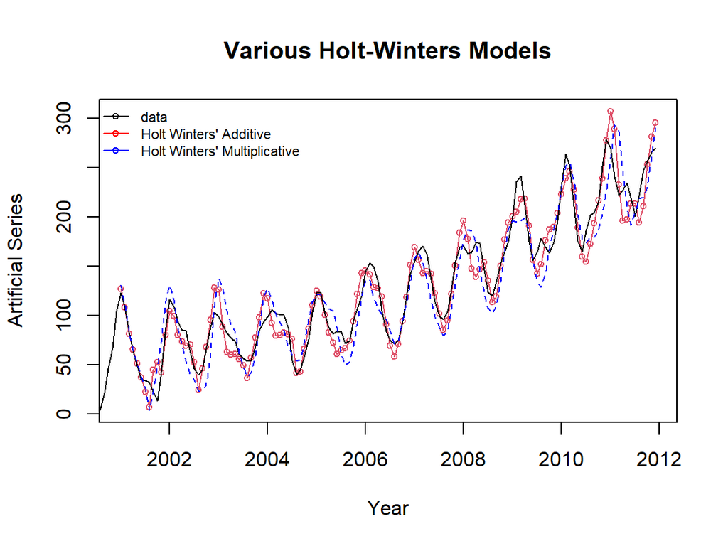

Comparing Holt’s exponential trend and seasonal models.

```r
dat01=read.table("https://raw.githubusercontent.com/pengdsci/sta321/main/ww13/w13-ts3.txt")
datset=ts(dat01$V1+55, start=2000, frequency=12)
## Model building
fit1 = HoltWinters(datset, seasonal="additive")   # default h = 10
fit2 = HoltWinters(datset, seasonal="multiplicative")
### plots
plot(fit1,ylab="Artificial Series",main="Various Holt-Winters Models",
     type="o", xlab="Year", cex = 0.7)
#lines(fitted(fit1)[,1], col="red", lty=2)
lines(fitted(fit2)[,1], col="blue", lty=2, cex = 0.7)
###
legend("topleft",lty=1, pch=1, col=c("black", "red", "blue"),
  c("data","Holt Winters' Additive","Holt Winters' Multiplicative"),
  cex = 0.7, bty = "n")
```

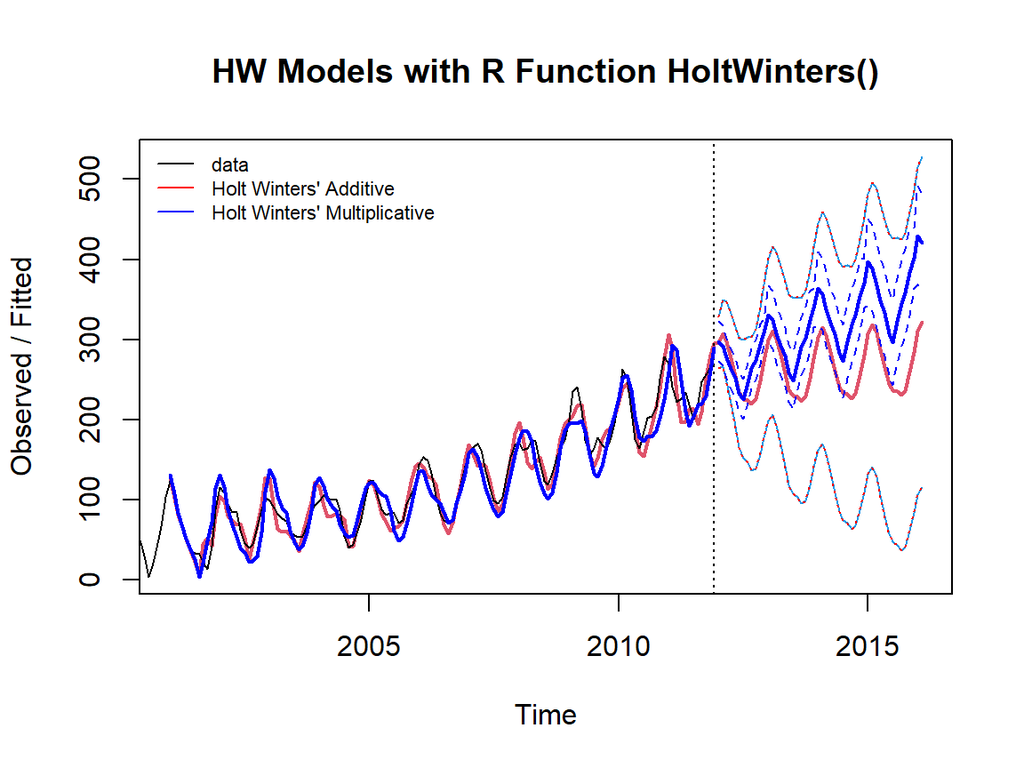

```r
pred = predict(fit1, 50, prediction.interval = TRUE)
pred2 = predict(fit2, 50, prediction.interval = TRUE)
plot(fit1, pred, lwd=2, main="HW Models with R Function HoltWinters()")
lines(pred[,2], col="red", lwd=1, lty=3)
lines(pred[,3], col="red", lwd=1, lty=3)
lines(fitted(fit2)[,1], col="blue", lty=1, lwd=2)
lines(pred2[,2], col="blue", lty=2)
lines(pred2[,1], col="blue", lty=1, lwd=2)
lines(pred2[,3], col="blue", lty=2)
legend("topleft",lty=1, col=c("black", "red", "blue"),
  c("data","Holt Winters' Additive","Holt Winters' Multiplicative"),
  cex = 0.7, bty = "n")
```

The above figure shows that the original series is a typical exponential trend with a seasonal pattern. As expected, the Holt-Winters additive model performed poorly (a very wide prediction band).

# 7 Case study

In this case study, we use the beverage consumption data to compare various models introduced in this note.

```r
beverage = read.table("https://raw.githubusercontent.com/pengdsci/sta321/main/ww13/w13-beverage01.txt")
test.bev = beverage$V1[169:180]
train.bev = beverage$V1[1:168]
bev=ts(beverage$V1[1:168], start=2000, frequency = 12)
fit1 = ses(bev, h=12)
fit2 = holt(bev, initial="optimal", h=12)             ## optimal alpha and beta
fit3 = holt(bev,damped=TRUE, h=12 )                   ## additive damping
fit4 = holt(bev,exponential=TRUE, damped=TRUE, h =12) ## multiplicative damp
fit5 = hw(bev,h=12, seasonal="additive")              ## default h = 10
fit6 = hw(bev,h=12, seasonal="multiplicative")
fit7 = hw(bev,h=12, seasonal="additive",damped=TRUE)
fit8 = hw(bev,h=12, seasonal="multiplicative",damped=TRUE)
```

```r
accuracy.table = round(rbind(accuracy(fit1), accuracy(fit2), accuracy(fit3), accuracy(fit4),
                             accuracy(fit5), accuracy(fit6), accuracy(fit7), accuracy(fit8)),4)
row.names(accuracy.table)=c("SES","Holt Linear","Holt Add. Damped", "Holt Exp. Damped",
                            "HW Add.","HW Exp.","HW Add. Damp", "HW Exp. Damp")
kable(accuracy.table, caption = "The accuracy measures of various exponential smoothing models
      based on the training data")
```

The accuracy measures of various exponential smoothing models based on the training data

|  | ME | RMSE | MAE | MPE | MAPE | MASE | ACF1 |
| --- | --- | --- | --- | --- | --- | --- | --- |
| SES | 16.5017 | 309.4093 | 257.6429 | 0.1583 | 5.0742 | 1.3090 | 0.0043 |
| Holt Linear | -2.5111 | 312.4926 | 262.2489 | -0.2495 | 5.2023 | 1.3324 | -0.0007 |
| Holt Add. Damped | 10.8546 | 311.8373 | 260.8383 | 0.0082 | 5.1661 | 1.3252 | -0.0016 |
| Holt Exp. Damped | 11.6379 | 312.2482 | 261.0031 | 0.0305 | 5.1699 | 1.3261 | -0.0029 |
| HW Add. | -8.3236 | 117.5757 | 91.9541 | -0.2135 | 1.7920 | 0.4672 | -0.0215 |
| HW Exp. | 2.3822 | 121.7157 | 95.9449 | -0.0051 | 1.8727 | 0.4875 | 0.1052 |
| HW Add. Damp | 11.7728 | 118.5088 | 93.8735 | 0.1786 | 1.8225 | 0.4769 | -0.0376 |
| HW Exp. Damp | 11.9044 | 118.6752 | 92.4620 | 0.1635 | 1.7994 | 0.4698 | -0.0900 |

The above table shows that the HW additive seems to be the most appropriate.

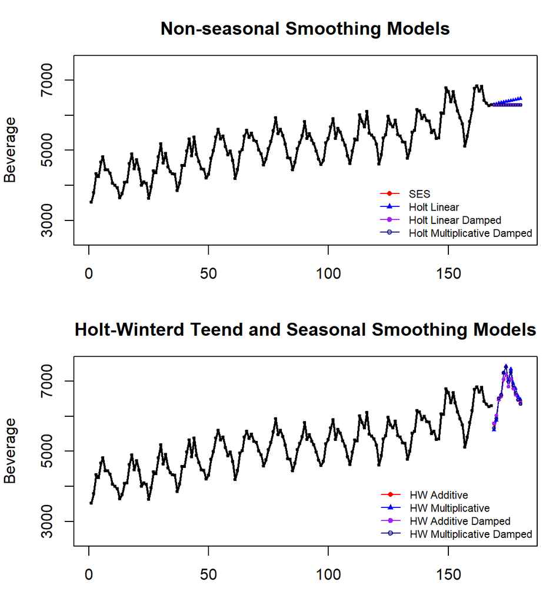

Case study: Comparing various exponential smoothing models.

```r
par(mfrow=c(2,1), mar=c(3,4,3,1))
###### plot the original data
pred.id = 169:180
plot(1:168, train.bev, lwd=2,type="o", ylab="Beverage", xlab="",
     xlim=c(1,180), ylim=c(2500, 7500), cex=0.3,
     main="Non-seasonal Smoothing Models")
lines(pred.id, fit1$mean, col="red")
lines(pred.id, fit2$mean, col="blue")
lines(pred.id, fit3$mean, col="purple")
lines(pred.id, fit4$mean, col="navy")
points(pred.id, fit1$mean, pch=16, col="red", cex = 0.5)
points(pred.id, fit2$mean, pch=17, col="blue", cex = 0.5)
points(pred.id, fit3$mean, pch=19, col="purple", cex = 0.5)
points(pred.id, fit4$mean, pch=21, col="navy", cex = 0.5)
#points(fit0, col="black", pch=1)
legend("bottomright", lty=1, col=c("red","blue","purple", "navy"),pch=c(16,17,19,21),
   c("SES","Holt Linear","Holt Linear Damped", "Holt Multiplicative Damped"),
   cex = 0.7, bty="n")
###########
plot(1:168, train.bev, lwd=2,type="o", ylab="Beverage", xlab="",
     xlim=c(1,180), ylim=c(2500, 7500), cex=0.3,
     main="Holt-Winterd Teend and Seasonal Smoothing Models")
lines(pred.id, fit5$mean, col="red")
lines(pred.id, fit6$mean, col="blue")
lines(pred.id, fit7$mean, col="purple")
lines(pred.id, fit8$mean, col="navy")
points(pred.id, fit5$mean, pch=16, col="red", cex = 0.5)
points(pred.id, fit6$mean, pch=17, col="blue", cex = 0.5)
points(pred.id, fit7$mean, pch=19, col="purple", cex = 0.5)
points(pred.id, fit8$mean, pch=21, col="navy", cex = 0.5)
###
legend("bottomright", lty=1, col=c("red","blue","purple", "navy"),pch=c(16,17,19,21),
   c("HW Additive","HW Multiplicative","HW Additive Damped", "HW Multiplicative Damped"),
   cex = 0.7, bty="n")
```

We can see from the above accuracy table that HW’s linear trend with an additive seasonal model is the best of the eight smoothing models. This is consistent with the patterns in the original serial plot.

Since we train the model with the training data and identify the best model using both training and testing data. Both methods yield the same results. To use the model for real-forecast, we need to refit the model using the entire data to update the smoothing parameters in the final working model.

```r
acc.fun = function(test.data, mod.obj){
  PE=100*(test.data-mod.obj$mean)/mod.obj$mean
  MAPE = mean(abs(PE))
  ###
  E=test.data-mod.obj$mean
  MSE=mean(E^2)
  ###
  accuracy.metric=c(MSE=MSE, MAPE=MAPE)
  accuracy.metric
}
```

```r
pred.accuracy = rbind(SES =acc.fun(test.data=test.bev, mod.obj=fit1),
                      Holt.Add =acc.fun(test.data=test.bev, mod.obj=fit2),
                      Holt.Add.Damp =acc.fun(test.data=test.bev, mod.obj=fit3),
                      Holt.Exp =acc.fun(test.data=test.bev, mod.obj=fit4),
                      HW.Add =acc.fun(test.data=test.bev, mod.obj=fit5),
                      HW.Exp =acc.fun(test.data=test.bev, mod.obj=fit6),
                      HW.Add.Damp =acc.fun(test.data=test.bev, mod.obj=fit7),
                      HW.Exp.Damp =acc.fun(test.data=test.bev, mod.obj=fit8))
kable(pred.accuracy, caption="The accuracy measures of various exponential smoothing models
      based on the testing data")
```

The accuracy measures of various exponential smoothing models based on the testing data

|  | MSE | MAPE |
| --- | --- | --- |
| SES | 268795.08 | 6.325197 |
| Holt.Add | 221347.08 | 5.411444 |
| Holt.Add.Damp | 268829.31 | 6.326006 |
| Holt.Exp | 267988.88 | 6.306752 |
| HW.Add | 49429.46 | 3.055574 |
| HW.Exp | 87301.79 | 3.607590 |
| HW.Add.Damp | 51295.11 | 3.091598 |
| HW.Exp.Damp | 72440.01 | 3.422931 |

We can see from the above accuracy table that HW’s linear trend with an additive seasonal model is the best of the eight smoothing models. This is consistent with the patterns in the original serial plot.

In the previous analysis, we train the model with the training data and identify the best model using both training and testing data. **In real-forecast, we need to refit the model at the very end using the entire data to update the smoothing parameters in the final working model**.

```r
beverage = read.table("https://raw.githubusercontent.com/pengdsci/sta321/main/ww13/w13-beverage01.txt")
bev=ts(beverage$V1[1:180], start=2000, frequency = 12)
final.model = hw(bev,h=12, seasonal="additive")
smoothing.parameter = final.model$model$par[1:3]
kable(smoothing.parameter, caption="Estimated values of the smoothing parameters in
      Holt-Winters linear trend with additive seasonality")
```

Estimated values of the smoothing parameters in Holt-Winters linear trend with additive seasonality

|  | x |
| --- | --- |
| alpha | 0.3443447 |
| beta | 0.0001004 |
| gamma | 0.0003443 |

In summary, the updated values of the three smoothing parameters in the Holt-Winters linear trend and with additive seasonality using the entire data are given in the above table.